# Terror Data Project

Evan Pennebaker, Cayden Dunn, Ezekiel Murphy

11/8/2018

## INTRO:

This markdown attempts to provide useful information for predictions on potential upcoming attacks, be it where they are or who is most likely to commit terrorist acts, this markdown can help these departments in preparing and deploying countermeasures. Its intended for anyone working for a government organization regarding national defense or overseas intelligence (DoD, CIA, FBI, Homeland Security, etc.). The Global Terrorism Database is an open-source database. The Global Terrorism Database includes systematic data on domestic as well as international terrorist incidents. Using this we attempt to answer these questions.

# Is terrorism increasing? What region is attacked the most? How are terrorist attacking us?

### Which region gets attcked the most

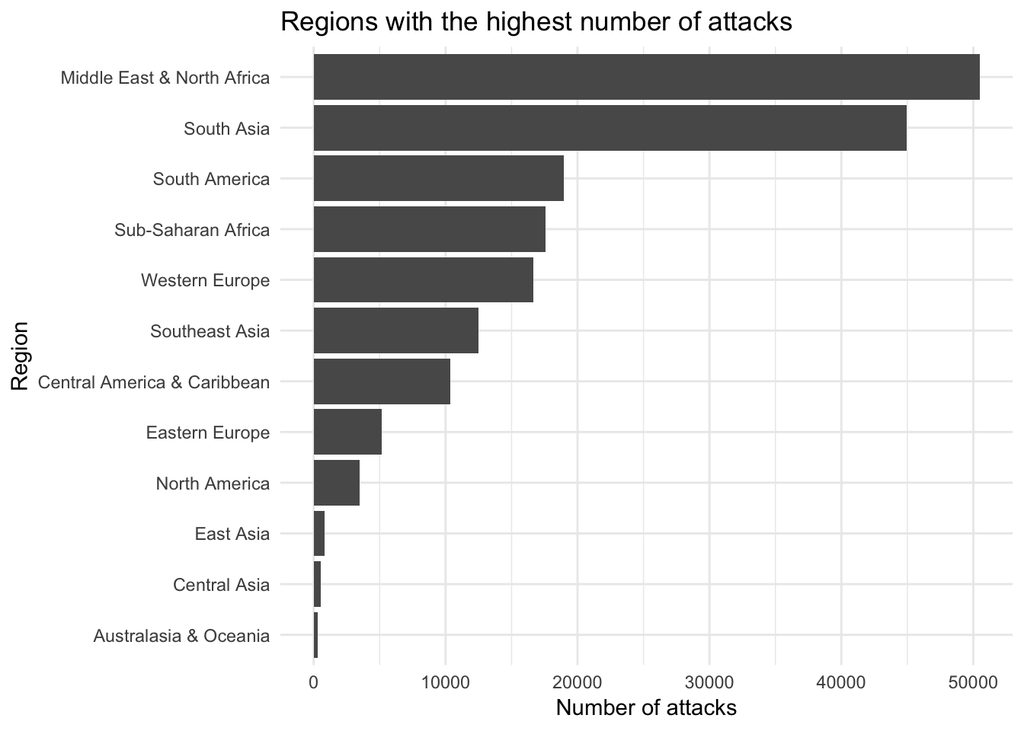

#### Description:

1. First a data frame d1 was created out of the vector region_txt that consisted of two columns a frequency column and a region column. Both were constructed using the the table of d$region_txt with frequency column holding the frequency of the table and the region column holding the region name.
2. then using ggplot a bar graph was created that displays the highest number of attacks per region. The only technical part of this step beside basic ggplot knowledge was reordering the regions to display from greatest to least which was done with a simple reorder of region by frequency.
3. the graphic ends up displays and communicating to the viewer the frequency of attacks per region.
4. Otherwise there are only some simple ggplot features that were used to make the bar plot look nice and more effectively communicate the information displayed.

### Has terrorism increased over the years

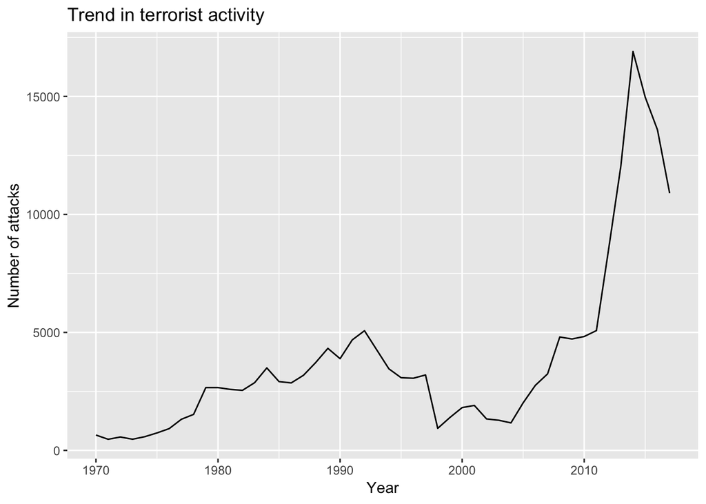

#### Take Away:

This graphic displays the frequency of terrorist attacks that happen per year ever since 1970. This graphic clearly displays the fact that after the year 2011 there was a significant spike in terrorist attacks. In fact after 2011 terrorist attacks nearly triple before seeing a quick decline. This graphic displays a clear spike in terrorist activity and can serve as a benchmark for how prevalent terrorist is global and how terror rates change over time as the model and data set are kept up to data as time goes on.

#### Description:

1. First a data frame d1 was created out of the vector iyear that consisted of two columns a frequency column and a years column. Both were constructed using the the table of d$iyear with frequency column holding the frequency of the table and the years column holding the year in which the attacks took place.
2. R was treating the years as numbers and throwing off ggplot so i treated d$iyear as numeric and this solved the problem but created another it made my tic marks on my graphic numeric so i added custom tick marks every 10 years to make the graphic communicate better to its intended audience
3. Then using ggplot i plotted using a line plot the frequency of attacks performed by terrorism per year.
4. the graphic ends up displays and communicating to the viewer the frequency of attacks per year.
5. Otherwise there are only some simple ggplot features that were used to make the bar plot look nice and more effectively communicate the information displayed.

### What type of Terroist Attack is most common

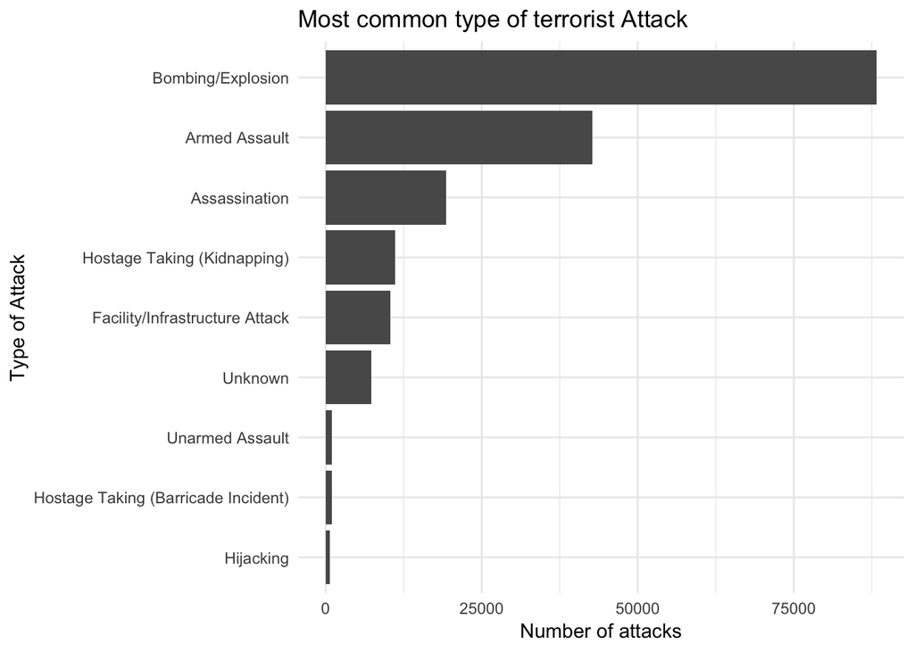

#### Take Away:

This graphic displays the frequency of a given type of terrorist attack carried out by terrorist since 1970. The graphic clearly displays that bombings and explosive attacks are the most prominent and most commonly used tool for terrorist to carry out attacks. in fact it’s twice as likely than than a terrorist using any other means to carry out an attack. This graphic can assist in deterring tering terrorist attacks because if we know which method is most common for the terrorist to use to attack us we can better prepare and fortify for the said type of attack.

#### Description:

1. First a data frame d1 was created out of the vector attacktype1_txt that consisted of two columns a frequency column and a typ_of_atk column. Both were constructed using the the table of d$attacktype1_txt with frequency column holding the frequency of the table and the typ_of_atk column holding the typ_of_atk name.
2. then using ggplot a bar graph was created that displays the highest number of attacks per method of attacking. The only technical part of this step beside basic ggplot knowledge was reordering the regions to display from greatest to least which was done with a simple reorder of type of attack by frequency.
3. the graphic ends up displays and communicating to the viewer the frequency of attacks per method of attacking.
4. Otherwise there are only some simple ggplot features that were used to make the bar plot look nice and more effectively communicate the information displayed.